# MIMIC-III SOFA & APACHE Analysis

April 2022

**Libraries Used:**

```r
# Data I/O
library('RPostgreSQL')    # access MIMIC-III
library('reshape2')       # melting dataframes
library('dplyr')          # misc. organization
library('data.table')

# Data preparation
library('psych')          # descriptive stats

# Plots and tables
library('knitr')          # knitting Rmd to HTML; kable() function
library('kableExtra')     # extra formating options for knitr tables
library('ggplot2')        # 2d plotting
library('ggpubr')         # extra formatting options for ggplot
```

**Random Seed Set**

```r
set.seed(123456)
```

# 1 Introduction

## 1.1 Background

The sequential organ failure assessment score (SOFA score), previously known as the sepsis-related organ failure assessment score, is used to track a person’s status during the stay in an intensive care unit (ICU) to determine the extent of a person’s organ function or rate of failure. The score is based on six different scores, one each for the respiratory, cardiovascular, hepatic, coagulation, renal and neurological systems.

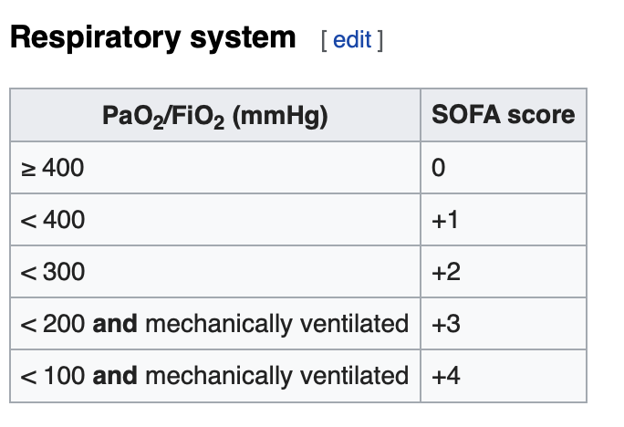

```r
knitr::include_graphics("sofa-1.png")
```

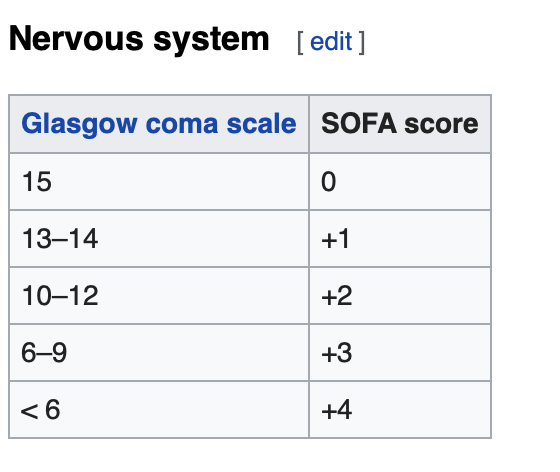

```r
knitr::include_graphics("sofa-2.png")
```

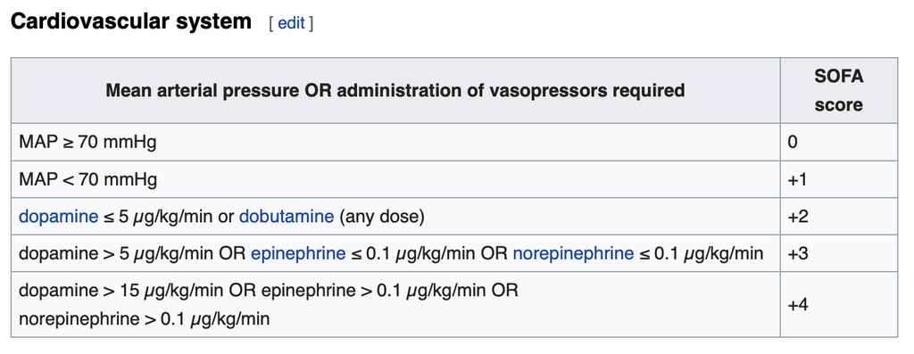

```r
knitr::include_graphics("sofa-3.png")
```

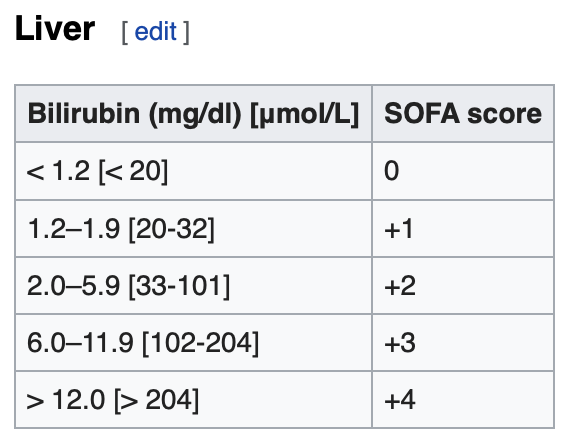

```r
knitr::include_graphics("sofa-4.png")
```

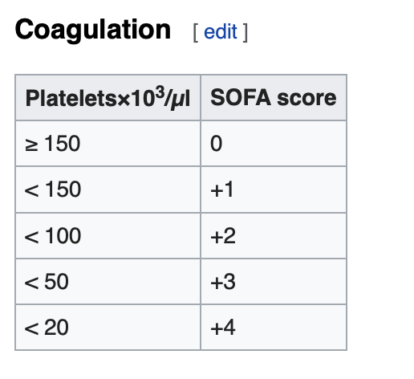

```r
knitr::include_graphics("sofa-5.png")
```

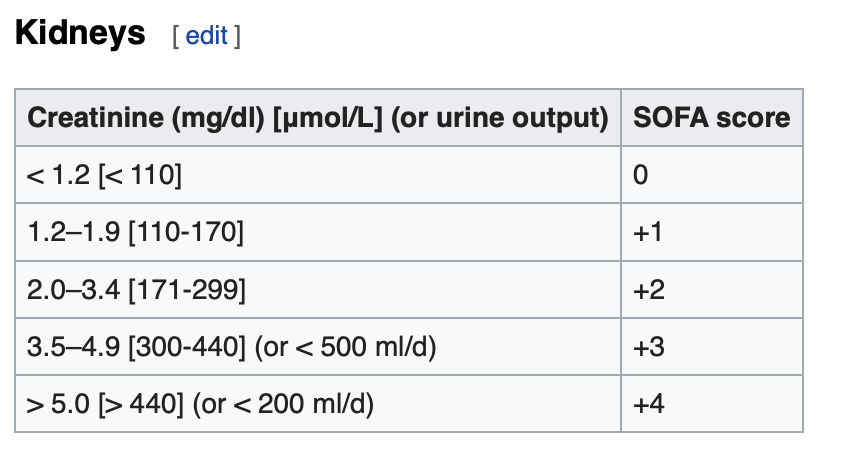

```r
knitr::include_graphics("sofa-6.png")
```

## 1.2 Quick SOFA Score

The Quick SOFA Score (quickSOFA or qSOFA) was introduced by the Sepsis-3 group in February 2016 as a simplified version of the SOFA Score as an initial way to identify patients at high risk for poor outcome with an infection. The SIRS Criteria definitions of sepsis are being replaced as they were found to possess too many limitations; the “current use of 2 or more SIRS criteria to identify sepsis was unanimously considered by the task force to be unhelpful.” The qSOFA simplifies the SOFA score drastically by only including its 3 clinical criteria and by including “any altered mentation” instead of requiring a GCS <15. qSOFA can easily and quickly be repeated serially on patients.

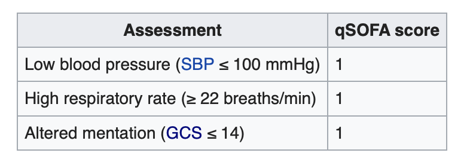

```r
knitr::include_graphics("quick sofa.png")
```

The score ranges from 0 to 3 points. The presence of 2 or more qSOFA points near the onset of infection was associated with a greater risk of death or prolonged intensive care unit stay. These are outcomes that are more common in infected patients who may be septic than those with uncomplicated infection. Based upon these findings, the Third International Consensus Definitions for Sepsis recommends qSOFA as a simple prompt to identify infected patients outside the ICU who are likely to be septic.

Source: https://en.wikipedia.org/wiki/SOFA_score

# 2 Data extraction and manipulation

## 2.1 Load the data

First, we are going to generate a list of patient ID included in the dataset.

`SELECT subject_id FROM diagnoses_icd`

```r
subject_id_list <- read.csv('subject_id.csv')
subject_id_list = unique(subject_id_list$subject_id)
```

After generating a list of subjects, we can extract the various diagnoses associated with them.

`SELECT * FROM d_icd_diagnoses`

```r
d_icd_diagnoses <- read.csv('d_icd_diagnosis.csv')
kable(head(d_icd_diagnoses), caption="Sample of `D_ICD_DIAGNOSES` SQL table") %>%
  kable_styling(bootstrap_options='striped')
```

Sample of `D_ICD_DIAGNOSES` SQL table

| row_id | icd9_code | short_title | long_title |
| --- | --- | --- | --- |
| 174 | 1166 | TB pneumonia-oth test | Tuberculous pneumonia [any form], tubercle bacilli not found by bacteriological or histological examination, but tuberculosis confirmed by other methods [inoculation of animals] |
| 175 | 1170 | TB pneumothorax-unspec | Tuberculous pneumothorax, unspecified |
| 176 | 1171 | TB pneumothorax-no exam | Tuberculous pneumothorax, bacteriological or histological examination not done |
| 177 | 1172 | TB pneumothorx-exam unkn | Tuberculous pneumothorax, bacteriological or histological examination unknown (at present) |
| 178 | 1173 | TB pneumothorax-micro dx | Tuberculous pneumothorax, tubercle bacilli found (in sputum) by microscopy |
| 179 | 1174 | TB pneumothorax-cult dx | Tuberculous pneumothorax, tubercle bacilli not found (in sputum) by microscopy, but found by bacterial culture |

Next, we can obtain a dataframe containing the diagnosis information for each patient.

`SELECT * FROM diagnoses_icd WHERE row_id in (SELECT row_id FROM d_icd_diagnosis)`

```r
diagnosis_icd <- read.csv('diagnoses_icd.csv')
cohort_data <- diagnosis_icd %>% group_by(subject_id) %>%
summarize(icd9_code = paste(sort(unique(icd9_code)),collapse=", "))
kable(head(cohort_data), caption="Sample dataframe returned by the DIAGNOSES_ICD table.") %>%
  kable_styling(bootstrap_options='striped')
```

Sample dataframe returned by the DIAGNOSES_ICD table.

| subject_id | icd9_code |
| --- | --- |
| 2 | V053, V290, V3001 |
| 3 | 0389, 2639, 41071, 4254, 4275, 4280, 5849, 6826, 78559 |
| 4 | 04111, 042, 1363, 2763, 5715, 7907, 7994, E9317, V090 |
| 5 | V053, V290, V3000 |
| 6 | 2753, 2766, 2767, 2859, 40391, 4440, 9972, V1582 |
| 7 | V053, V290, V3001 |

## 2.2 Screen the patients

We’ll screen the patients based on their ICD9 codes to identify those with sepsis based on a post in [Stack Overflow](https://stackoverflow.com/questions/50672316/r-test-if-a-string-vector-contains-any-element-of-another-list). The codes for sepsis, severe sepsis, and septic shock are 99591, 99592, and 78552 respectively.

```r
# Search for septic patients
search_patterns = paste(c(99591, 99592, 78552), collapse="|")

for (i in 1:nrow(cohort_data)){
  cohort_data$septic[i] <- grepl(search_patterns, cohort_data[i, 'icd9_code'])
}

kable(head(cohort_data), caption="Sample of cohort data from Part 1 after searching for sepsis diagnosis.") %>%
  kable_styling(bootstrap_options='striped')
```

Sample of cohort data from Part 1 after searching for sepsis diagnosis.

| subject_id | icd9_code | septic |
| --- | --- | --- |
| 2 | V053, V290, V3001 | FALSE |
| 3 | 0389, 2639, 41071, 4254, 4275, 4280, 5849, 6826, 78559 | FALSE |
| 4 | 04111, 042, 1363, 2763, 5715, 7907, 7994, E9317, V090 | FALSE |
| 5 | V053, V290, V3000 | FALSE |
| 6 | 2753, 2766, 2767, 2859, 40391, 4440, 9972, V1582 | FALSE |
| 7 | V053, V290, V3001 | FALSE |

## 2.3 Extract GCS (Glasgow Coma Scale)

Extract motor response:

```r
Motor <- read.csv('GCS Motor.csv')
Motor_2 <- read.csv('GCS_Motor 2.csv')
Motor <- rbind(Motor, Motor_2)
Motor <- Motor[!duplicated(Motor$subject_id),]
kable(head(Motor), caption="Motor Response") %>%
  kable_styling(bootstrap_options='striped')
```

Motor Response

| subject_id | valuenum |
| --- | --- |
| 4 | 6 |
| 13 | 6 |
| 19 | 6 |
| 3 | 6 |
| 12 | 5 |
| 25 | 6 |

Extract verbal response:

```r
Verbal <- read.csv('GCS Verbal.csv')
Verbal_2 <- read.csv('GCS_Verbal 2.csv')
Verbal <- rbind(Verbal, Verbal_2)
Verbal <- Verbal[!duplicated(Verbal$subject_id),]
kable(head(Verbal), caption="Verbal Response") %>%
  kable_styling(bootstrap_options='striped')
```

Verbal Response

| subject_id | valuenum |
| --- | --- |
| 4 | 5 |
| 13 | 5 |
| 28 | 5 |
| 9 | 1 |
| 19 | 4 |
| 21 | 5 |

Extract eyes response:

```r
Eyes <- read.csv('GCS Eyes.csv')
Eyes_2 <- read.csv('GCS_Eyes 2.csv')
Eyes <- rbind(Eyes, Eyes_2)
Eyes <- Eyes[!duplicated(Eyes$subject_id),]
kable(head(Eyes), caption="Eyes Response") %>%
  kable_styling(bootstrap_options='striped')
```

Eyes Response

| subject_id | valuenum |
| --- | --- |
| 4 | 4 |
| 6 | 4 |
| 13 | 4 |
| 9 | 1 |
| 19 | 4 |
| 11 | 4 |

Merge GCS Responses

```r
GCS_data <- merge(Motor, Verbal, by=c('subject_id'), all=T)
GCS_data <- merge(GCS_data, Eyes, by=c('subject_id'), all=T)
colnames(GCS_data)[2] <- "Motor"
colnames(GCS_data)[3] <- "Verbal"
colnames(GCS_data)[4] <- "Eyes"
GCS_data = GCS_data[complete.cases(GCS_data),]
kable(head(GCS_data), caption="GCS") %>%
  kable_styling(bootstrap_options='striped')
```

GCS

| subject_id | Motor | Verbal | Eyes |
| --- | --- | --- | --- |
| 3 | 6 | 1 | 4 |
| 4 | 6 | 5 | 4 |
| 6 | 6 | 5 | 4 |
| 9 | 5 | 1 | 1 |
| 11 | 6 | 5 | 4 |
| 12 | 5 | 4 | 4 |

```r
for (i in 1:nrow(GCS_data)) {
  GCS_data$GCS[i] <- sum(as.numeric(GCS_data$Motor[i]), as.numeric(GCS_data$Verbal[i]), as.numeric(GCS_data$Eyes[i]))
}
kable(head(GCS_data), caption="GCS") %>%
  kable_styling(bootstrap_options='striped')
```

GCS

| subject_id | Motor | Verbal | Eyes | GCS |
| --- | --- | --- | --- | --- |
| 3 | 6 | 1 | 4 | 11 |
| 4 | 6 | 5 | 4 | 15 |
| 6 | 6 | 5 | 4 | 15 |
| 9 | 5 | 1 | 1 | 7 |
| 11 | 6 | 5 | 4 | 15 |
| 12 | 5 | 4 | 4 | 13 |

Merge the GCS data with `cohort_data`

```r
cohort_data <- merge(cohort_data, GCS_data[,c('subject_id', 'GCS')], by=c('subject_id'), all=T)
kable(head(cohort_data), caption="cohort_data") %>%
  kable_styling(bootstrap_options='striped')
```

cohort_data

| subject_id | icd9_code | septic | GCS |
| --- | --- | --- | --- |
| 2 | V053, V290, V3001 | FALSE | NA |
| 3 | 0389, 2639, 41071, 4254, 4275, 4280, 5849, 6826, 78559 | FALSE | 11 |
| 4 | 04111, 042, 1363, 2763, 5715, 7907, 7994, E9317, V090 | FALSE | 15 |
| 5 | V053, V290, V3000 | FALSE | NA |
| 6 | 2753, 2766, 2767, 2859, 40391, 4440, 9972, V1582 | FALSE | 15 |
| 7 | V053, V290, V3001 | FALSE | NA |

## 2.4 Extract Systolic blood pressure

`Select subject_id, valuenum from chartevents` `where itemid in (51, 442, 455, 6701, 220197, 220050, 456, 52, 6702, 443, 220052, 220181, 225312)`

```r
SBP_1 <- read.csv('SBP.csv')
SBP_2 <- read.csv('NBP Mean.csv')
SBP_3 <- read.csv('SBP_2.csv')
SBP_4 <- read.csv('Arterial BP Mean.csv')
SBP_5 <- read.csv('Arterial BP Mean #2.csv')
SBP_6 <- read.csv('SBP 2.csv')
SBP_7 <- read.csv('SBP 3.csv')
SBP <- rbind(SBP_1, SBP_2)
SBP <- rbind(SBP, SBP_3)
SBP <- rbind(SBP, SBP_4)
SBP <- rbind(SBP, SBP_5)
SBP <- rbind(SBP, SBP_6)
SBP <- rbind(SBP, SBP_7)
SBP <- SBP[!duplicated(SBP$subject_id),]
colnames(SBP)[2] <- "SBP"
kable(head(SBP), caption="SBP") %>%
  kable_styling(bootstrap_options='striped')
```

SBP

|  | subject_id | SBP |
| --- | --- | --- |
| 1 | 103 | 159 |
| 3 | 145 | 129 |
| 8 | 111 | 80 |
| 13 | 130 | 121 |
| 16 | 132 | 125 |
| 28 | 96 | 132 |

Merge the SBP data with `cohort_data`

```r
cohort_data <- merge(cohort_data, SBP[,c('subject_id', 'SBP')], by=c('subject_id'), all=T)
kable(head(cohort_data), caption="cohort_data") %>%
  kable_styling(bootstrap_options='striped')
```

cohort_data

| subject_id | icd9_code | septic | GCS | SBP |
| --- | --- | --- | --- | --- |
| 2 | V053, V290, V3001 | FALSE | NA | NA |
| 3 | 0389, 2639, 41071, 4254, 4275, 4280, 5849, 6826, 78559 | FALSE | 11 | 87 |
| 4 | 04111, 042, 1363, 2763, 5715, 7907, 7994, E9317, V090 | FALSE | 15 | 75 |
| 5 | V053, V290, V3000 | FALSE | NA | NA |
| 6 | 2753, 2766, 2767, 2859, 40391, 4440, 9972, V1582 | FALSE | 15 | 167 |
| 7 | V053, V290, V3001 | FALSE | NA | NA |

## 2.5 Extract Respiratory Rate

`Select subject_id, valuenum` `from chartevents where itemid = 220210 or itemid = 618 or itemid = 615 or itemid = 224690`

```r
RR <- read.csv('RR.csv')
RR_1 <- read.csv('RR_total.csv')
RR_2 <- read.csv('RR_total_2.csv')
RR_3 <- read.csv('RR_2.csv')
RR <- rbind(RR, RR_1)
RR <- rbind(RR, RR_2)
RR <- rbind(RR, RR_3)
RR <- RR[!duplicated(RR$subject_id),]
colnames(RR)[2] <- "respiratory_rate"
kable(head(RR), caption="Respiratory Rate") %>%
  kable_styling(bootstrap_options='striped')
```

Respiratory Rate

|  | subject_id | respiratory_rate |
| --- | --- | --- |
| 1 | 4 | 24 |
| 2 | 13 | 12 |
| 4 | 26 | 24 |
| 5 | 28 | 15 |
| 6 | 9 | 14 |
| 10 | 19 | 20 |

Merge the Respiratory Rate data with `cohort_data`

```r
cohort_data <- merge(cohort_data, RR[,c('subject_id', 'respiratory_rate')], by=c('subject_id'), all=T)
kable(head(cohort_data), caption="cohort_data") %>%
  kable_styling(bootstrap_options='striped')
```

cohort_data

| subject_id | icd9_code | septic | GCS | SBP | respiratory_rate |
| --- | --- | --- | --- | --- | --- |
| 2 | V053, V290, V3001 | FALSE | NA | NA | NA |
| 3 | 0389, 2639, 41071, 4254, 4275, 4280, 5849, 6826, 78559 | FALSE | 11 | 87 | 16 |
| 4 | 04111, 042, 1363, 2763, 5715, 7907, 7994, E9317, V090 | FALSE | 15 | 75 | 24 |
| 5 | V053, V290, V3000 | FALSE | NA | NA | NA |
| 6 | 2753, 2766, 2767, 2859, 40391, 4440, 9972, V1582 | FALSE | 15 | 167 | 10 |
| 7 | V053, V290, V3001 | FALSE | NA | NA | NA |

## 2.6 Prepare data

Withe all the variables we need for quick SOFA score, we’ll choose to remove rows that contain missing variables in order to make visualization and exploratory data analysis easier.

```r
cohort_data = cohort_data[complete.cases(cohort_data),]
kable(head(cohort_data), caption="cohort_data") %>%
  kable_styling(bootstrap_options='striped')
```

cohort_data

|  | subject_id | icd9_code | septic | GCS | SBP | respiratory_rate |
| --- | --- | --- | --- | --- | --- | --- |
| 2 | 3 | 0389, 2639, 41071, 4254, 4275, 4280, 5849, 6826, 78559 | FALSE | 11 | 87 | 16 |
| 3 | 4 | 04111, 042, 1363, 2763, 5715, 7907, 7994, E9317, V090 | FALSE | 15 | 75 | 24 |
| 5 | 6 | 2753, 2766, 2767, 2859, 40391, 4440, 9972, V1582 | FALSE | 15 | 167 | 10 |
| 8 | 9 | 2765, 4019, 4280, 431, 5070, 5849 | FALSE | 7 | 81 | 14 |
| 10 | 11 | 1913 | FALSE | 15 | 67 | 19 |
| 11 | 12 | 1570, 4019, 4275, 55321, 5680, 57410, 9971, 99811, E8782 | FALSE | 13 | 145 | 26 |

## 2.7 Calculate qSOFA score

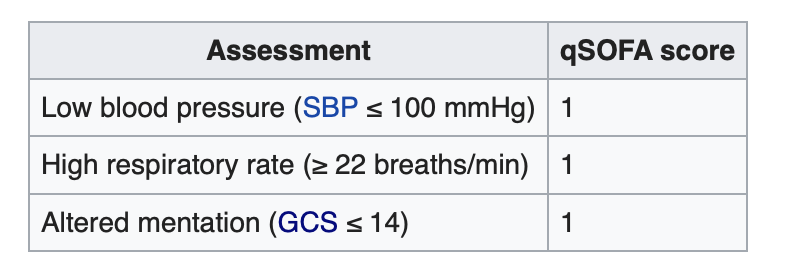

```r
knitr::include_graphics("quick sofa.png")
```

```r
for (i in 1:nrow(cohort_data)) {
  cohort_data$qSOFA[i] <-sum(as.numeric(cohort_data$SBP[i] <= 100),
                                  as.numeric(cohort_data$respiratory_rate[i] >= 22),
                                  as.numeric(cohort_data$GCS[i] <= 14))
}
kable(head(cohort_data), caption="cohort_data") %>%
  kable_styling(bootstrap_options='striped')
```

cohort_data

|  | subject_id | icd9_code | septic | GCS | SBP | respiratory_rate | qSOFA |
| --- | --- | --- | --- | --- | --- | --- | --- |
| 2 | 3 | 0389, 2639, 41071, 4254, 4275, 4280, 5849, 6826, 78559 | FALSE | 11 | 87 | 16 | 2 |
| 3 | 4 | 04111, 042, 1363, 2763, 5715, 7907, 7994, E9317, V090 | FALSE | 15 | 75 | 24 | 2 |
| 5 | 6 | 2753, 2766, 2767, 2859, 40391, 4440, 9972, V1582 | FALSE | 15 | 167 | 10 | 0 |
| 8 | 9 | 2765, 4019, 4280, 431, 5070, 5849 | FALSE | 7 | 81 | 14 | 2 |
| 10 | 11 | 1913 | FALSE | 15 | 67 | 19 | 1 |
| 11 | 12 | 1570, 4019, 4275, 55321, 5680, 57410, 9971, 99811, E8782 | FALSE | 13 | 145 | 26 | 2 |

# 3 Model Training - qSOFA

To prepare the data for our classifier, we are going to divide the dataset into training and test datasets.

```r
set.seed(12345)
subset_int <- sample(nrow(cohort_data), floor(nrow(cohort_data)*0.6))
# 60% training + 40% testing
cohort_data_train <- cohort_data[subset_int, ]
cohort_data_test <- cohort_data[-subset_int, ]
```

Let’s examine the distribution of sepsis in the training and test datasets.

```r
prop.table(table(cohort_data_train$septic))
```

```
##
##     FALSE      TRUE
## 0.8688525 0.1311475
```

```r
prop.table(table(cohort_data_test$septic))
```

```
##
##     FALSE      TRUE
## 0.8333333 0.1666667
```

The package we are going to use for Naive Bayes classifier is called `e1071`. For our first model training, we are going to train the model using the qSOFA score

```r
# install.packages("e1071", repos = "http://cran.us.r-project.org")
library(e1071)
# build the classifier
classifier <- naiveBayes(cohort_data_train[,c("qSOFA")], as.factor(cohort_data_train$septic))
```

The function `naiveBayes()` has following components: `m <- naiveBayes(train, class, laplace=0)`

- train: data frame containing numeric training data (features)
- class: factor vector with the class for each row in the training data
- laplace: positive double controlling Laplace smoothing; default is 0 and disables Laplace smoothing.

```r
# use the classifier to make predictions
pred <- predict(classifier, cohort_data_test)
```

The function `predict()` has the following components: `p <- predict(m, test, type = "class")`

- m: classifier trained by `naiveBayes()`
- test: test data frame or matric
- type: either `"class"` or `"raw"` specifies whether the predictions should be the most likely class value or the raw predicted probabilities.

## 3.1 Evaluate model performance

Here we are using cross table to compare predicted class and the true class of our test dataset.

The package we are using for model performance evaluation is called `gmodels`.

```r
#install.packages(c("gmodels"))
library(gmodels)
```

```r
CrossTable(pred, cohort_data_test$septic)
```

```
##
##
##    Cell Contents
## |-------------------------|
## |                       N |
## |         N / Table Total |
## |-------------------------|
##
##
## Total Observations in Table:  42
##
##
##              | cohort_data_test$septic
##         pred |     FALSE |      TRUE | Row Total |
## -------------|-----------|-----------|-----------|
##        FALSE |        35 |         7 |        42 |
##              |     0.833 |     0.167 |           |
## -------------|-----------|-----------|-----------|
## Column Total |        35 |         7 |        42 |
## -------------|-----------|-----------|-----------|
##
##
```

The model fails to predict anyone that’s septic as true.

Accuracy: 35/42 = 83.3%

# 4 Model Training - GCS, SBP, respiratory rate

```r
# install.packages("e1071", repos = "http://cran.us.r-project.org")
library(e1071)
# build the classifier
classifier <- naiveBayes(cohort_data_train[,c("GCS", "SBP", "respiratory_rate")], as.factor(cohort_data_train$septic))
```

The function `naiveBayes()` has following components: `m <- naiveBayes(train, class, laplace=0)`

- train: data frame containing numeric training data (features)
- class: factor vector with the class for each row in the training data
- laplace: positive double controlling Laplace smoothing; default is 0 and disables Laplace smoothing.

```r
# use the classifier to make predictions
pred <- predict(classifier, cohort_data_test)
```

The function `predict()` has the following components: `p <- predict(m, test, type = "class")`

- m: classifier trained by `naiveBayes()`
- test: test data frame or matric
- type: either `"class"` or `"raw"` specifies whether the predictions should be the most likely class value or the raw predicted probabilities.

## 4.1 Evaluate model performance

Here we are using cross table to compare predicted class and the true class of our test dataset.

The package we are using for model performance evaluation is called `gmodels`.

```r
#install.packages(c("gmodels"))
library(gmodels)
```

```r
CrossTable(pred, cohort_data_test$septic)
```

```
##
##
##    Cell Contents
## |-------------------------|
## |                       N |
## |         N / Table Total |
## |-------------------------|
##
##
## Total Observations in Table:  42
##
##
##              | cohort_data_test$septic
##         pred |     FALSE |      TRUE | Row Total |
## -------------|-----------|-----------|-----------|
##        FALSE |        35 |         7 |        42 |
##              |     0.833 |     0.167 |           |
## -------------|-----------|-----------|-----------|
## Column Total |        35 |         7 |        42 |
## -------------|-----------|-----------|-----------|
##
##
```

Accuracy: 35/42 = 83%

Note: A follow-up study is done by constructing a Naive Bayes classifier with SIRS score along with other features to improve model performance. See the follow-up study here: [SIRS-Naive-Bayes] (https://yyyyyyou.github.io/SIRS-Naive-Bayes/)